# 15. Transformer로 번역기 만들기 [프로젝트]

## 15-1. 프로젝트: 더 멋진 번역기 만들기

### 라이브러리 버전 확인

```python
import tensorflow
import numpy
import matplotlib

print(tensorflow.__version__)
print(numpy.__version__)
print(matplotlib.__version__)
```

```
2.6.0
1.21.4
3.4.3
```

### Step 1. 데이터 가져오기 (클라우드 유저용)

```python
# 데이터 저장 위치 확인
```

```python
import os

file_path = os.getenv('HOME')+'/aiffel/transformer/data'
print(file_path)
```

```
/aiffel/aiffel/transformer/data
```

```python
file_list = os.listdir(file_path)  # 주어진 경로에 있는 파일 및 폴더 목록 가져오기
```

```python
for file in file_list:  # 파일 및 폴더 목록 출력
    print(file)
```

```
korean-english-park.train.en
korean-english-park.train.ko
```

```python
# 데이터 가져오기
```

```python
data_dir = os.getenv('HOME')+'/aiffel/transformer/data'
kor_path = data_dir+"/korean-english-park.train.ko"
eng_path = data_dir+"/korean-english-park.train.en"
```

### Step 2. 데이터 정제 및 토큰화

#### 1. 중복 데이터 제거

- set 데이터형 활용
- 데이터의 병렬 쌍 유지
- 중복을 제거한 데이터를 cleaned_corpus 에 저장

```python
def clean_corpus(kor_path, eng_path):
    with open(kor_path, "r") as f:
        kor = f.read().splitlines()
    with open(eng_path, "r") as f:
        eng = f.read().splitlines()
    assert len(kor) == len(eng)

    # 두 언어의 문장 쌍을 튜플로 묶기
    corpus_list = list(zip(kor, eng))

    # 중복 제거
    cleaned_corpus_list = list(set(corpus_list))

    # 다시 한국어와 영어로 분리
    kor_cleaned, eng_cleaned = zip(*cleaned_corpus_list)
    cleaned_corpus = list(zip(kor_cleaned, eng_cleaned))

    return cleaned_corpus
```

```python
cleaned_corpus = clean_corpus(kor_path, eng_path)
```

#### 2. 문자 정제

- 모든 입력을 소문자로 변환합니다.
- 알파벳, 문장부호, 한글만 남기고 모두 제거합니다.
- 문장부호 양옆에 공백을 추가합니다.
- 문장 앞뒤의 불필요한 공백을 제거합니다.

```python
def preprocess_sentence(sentence):
    # 1. 모든 입력을 소문자로 변환
    sentence = sentence.lower()
    # 2. 알파벳, 문장부호, 한글만 남기기
    sentence = re.sub(r"[^a-zA-Z?.!,ㄱ-ㅎㅏ-ㅣ가-힣 ]", "", sentence)
    # 3. 문장부호 양옆에 공백 추가
    sentence = re.sub(r"([?.!,])", r" \1 ", sentence)
    # 공백 패턴을 하나의 공백으로 변경
    sentence = re.sub(r'[" "]+', " ", sentence)
    # 4. 문장 앞뒤의 불필요한 공백 제거
    sentence = sentence.strip()

    return sentence
```

#### 3, 토큰화

```python
# Sentencepiece를 활용하여 학습한 tokenizer를 생성합니다.
```

```python
import sentencepiece as spm
import re
```

```python
def generate_tokenizer(corpus,
                        vocab_size,
                        lang="ko",
                        pad_id=0,
                        bos_id=1,
                        eos_id=2,
                        unk_id=3):
    # 임시 텍스트 파일 생성
    temp_file = f"./{lang}_temp.txt"
    with open(temp_file, "w", encoding="utf-8") as f:
        for sentence in corpus:
            f.write(sentence + "\n")

    # SentencePiece 학습
    spm.SentencePieceTrainer.Train(
        f"--input={temp_file} --model_prefix={lang}_spm --vocab_size={vocab_size}" +
        f" --pad_id={pad_id} --bos_id={bos_id} --eos_id={eos_id} --unk_id={unk_id}"
    )

    # 학습된 모델 로드
    tokenizer = spm.SentencePieceProcessor()
    tokenizer.Load(f"{lang}_spm.model")

    # 임시 파일 삭제
    os.remove(temp_file)

    return tokenizer
```

```python
SRC_VOCAB_SIZE = TGT_VOCAB_SIZE = 20000

eng_corpus = []
kor_corpus = []

for pair in cleaned_corpus:
    k, e = pair

    kor_corpus.append(preprocess_sentence(k))
    eng_corpus.append(preprocess_sentence(e))
```

```python
ko_tokenizer = generate_tokenizer(kor_corpus, SRC_VOCAB_SIZE, "ko")
en_tokenizer = generate_tokenizer(eng_corpus, TGT_VOCAB_SIZE, "en")
en_tokenizer.set_encode_extra_options("bos:eos")
```

[output not shown]

[output cut: 89 more lines]

[output not shown]

```
True
```

[output not shown]

#### 4. 데이터(corpus) 길이 제한

- 토크나이저를 활용해 토큰의 길이가 50 이하인 데이터를 선별하여
- src_corpus 와 tgt_corpus 를 각각 구축하고,
- 텐서 enc_train 과 dec_train 으로 변환하세요.

```python
from tqdm.notebook import tqdm
import tensorflow as tf

src_corpus = []
tgt_corpus = []

assert len(kor_corpus) == len(eng_corpus)

# 토큰의 길이가 50 이하인 문장만 남깁니다.
for idx in tqdm(range(len(kor_corpus))):
    # 한국어 문장 토큰화
    src_tokens = ko_tokenizer.EncodeAsIds(kor_corpus[idx])

    # 영어 문장 토큰화
    tgt_tokens = en_tokenizer.EncodeAsIds(eng_corpus[idx])

    # 토큰의 길이가 50 이하인 경우만 추가
    if len(src_tokens) <= 50 and len(tgt_tokens) <= 50:
        src_corpus.append(src_tokens)
        tgt_corpus.append(tgt_tokens)
```

```python
# 패딩처리로 학습용 데이터 완성
enc_train = tf.keras.preprocessing.sequence.pad_sequences(src_corpus, padding='post')
dec_train = tf.keras.preprocessing.sequence.pad_sequences(tgt_corpus, padding='post')
```

```python
enc_train
```

```
array([[ 9814,  3198,    10, ...,     0,     0,     0],
       [   82, 10301,    81, ...,     0,     0,     0],
       [15804,   279,  2581, ...,     0,     0,     0],
       ...,
       [  397,    94,    48, ...,     0,     0,     0],
       [ 1015,    22,  1987, ...,     0,     0,     0],
       [10394,    13,    39, ...,     0,     0,     0]], dtype=int32)
```

```python
dec_train
```

```
array([[   1, 1936,   48, ...,    0,    0,    0],
       [   1,  151,   43, ...,    0,    0,    0],
       [   1,   88,   38, ...,    0,    0,    0],
       ...,
       [   1,   62,  633, ...,    0,    0,    0],
       [   1,    4,   57, ...,    0,    0,    0],
       [   1,    9, 2960, ...,    0,    0,    0]], dtype=int32)
```

### Step 3. 모델 설계

### 1) 내부 모듈 구현하기

```python
# 필요 라이브러리 import
```

```python
import numpy as np
import tensorflow as tf
import matplotlib.pyplot as plt

import re
import os
import io
import time
import random

import seaborn

print(tf.__version__)
```

```
2.6.0
```

##### Positional Encoding

```python
def positional_encoding(pos, d_model):
    def cal_angle(position, i):
        return position / np.power(10000, int(i) / d_model)

    def get_posi_angle_vec(position):
        return [cal_angle(position, i) for i in range(d_model)]

    sinusoid_table = np.array([get_posi_angle_vec(pos_i) for pos_i in range(pos)])
    sinusoid_table[:, 0::2] = np.sin(sinusoid_table[:, 0::2])
    sinusoid_table[:, 1::2] = np.cos(sinusoid_table[:, 1::2])
    return sinusoid_table
```

```python
# 다차원 Positional Encoding 그래프 표현
```

```python
!pip install altair
```

[output not shown]

```python
import pandas as pd
import altair as alt

def plot_positional_encodings():
    y = positional_encoding(100, 20)
    data = pd.concat(
        [
            pd.DataFrame(
                {
                    "embedding": y[:, dim],
                    "dimension": dim,
                    "position": list(range(100)),
                }
            )
            for dim in [4, 5, 6, 7]
        ]
    )

    chart = (
        alt.Chart(data)
        .mark_line()
        .properties(width=800)
        .encode(x="position", y="embedding", color="dimension:N")
        .interactive()
    )

    return chart

# 그래프 출력
plot_positional_encodings()
```

[interactive chart not shown]

```python
# 깊이와 위치에 따른 positional encoding의 히트맵 표현
```

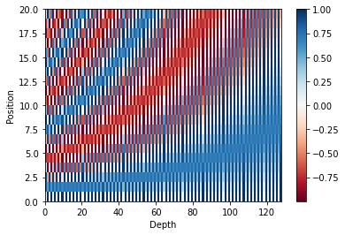

```python
sample_pos_encoding = positional_encoding(20, 512)

plt.pcolormesh(sample_pos_encoding, cmap='RdBu')
plt.xlabel('Depth')
plt.xlim((0, 128))
plt.ylabel('Position')
plt.colorbar()
plt.show()
```

##### Multi-Head Attention

```python
class MultiHeadAttention(tf.keras.layers.Layer):
    def __init__(self, d_model, num_heads):
        super(MultiHeadAttention, self).__init__()
        self.num_heads = num_heads
        self.d_model = d_model

        self.depth = d_model // self.num_heads

        self.W_q = tf.keras.layers.Dense(d_model)
        self.W_k = tf.keras.layers.Dense(d_model)
        self.W_v = tf.keras.layers.Dense(d_model)

        self.linear = tf.keras.layers.Dense(d_model)

    def scaled_dot_product_attention(self, Q, K, V, mask):
        d_k = tf.cast(K.shape[-1], tf.float32)
        QK = tf.matmul(Q, K, transpose_b=True)

        scaled_qk = QK / tf.math.sqrt(d_k)              # Scaled QK 값 구하기

        if mask is not None: scaled_qk += (mask * -1e9)

        attentions = tf.nn.softmax(scaled_qk, axis=-1)  # Attention Weights 값 구하기
        out = tf.matmul(attentions, V)                  # Attention 값을 V에 곱하기

        return out, attentions


    # Embedding을 Head의 수로 분할하는 함수
    def split_heads(self, x):     # x: [ batch x length x emb ]
        batch_size = x.shape[0]
        split_x = tf.reshape(x, (batch_size, -1, self.num_heads, self.depth))
        split_x = tf.transpose(split_x, perm=[0, 2, 1, 3])

        return split_x           # [ batch x heads x length x self.depth ]

    # 분할된 Embedding을 하나로 결합하는 함수
    def combine_heads(self, x):  # x: [ batch x heads x length x self.depth ]
        batch_size = x.shape[0]
        combined_x = tf.transpose(x, perm=[0, 2, 1, 3])
        combined_x = tf.reshape(combined_x, (batch_size, -1, self.d_model))

        return combined_x        # [ batch x length x emb ]


    def call(self, Q, K, V, mask):
        # Step 1: Linear_in(Q, K, V) -> WQ, WK, WV
        WQ = self.W_q(Q)
        WK = self.W_k(K)
        WV = self.W_v(V)

        # Step 2: Split Heads(WQ, WK, WV) -> WQ_split, WK_split, WV_split
        WQ_splits = self.split_heads(WQ)
        WK_splits = self.split_heads(WK)
        WV_splits = self.split_heads(WV)

        # Step 3: Scaled Dot Product Attention(WQ_split, WK_split, WV_split) -> out, attention_weights
        out, attention_weights = self.scaled_dot_product_attention(
            WQ_splits, WK_splits, WV_splits, mask)

        out = self.combine_heads(out)  # Step 4: Combine Heads(out) -> out
        out = self.linear(out)         # Step 5: Linear_out(out) -> out

        return out, attention_weights
```

##### Position-wise Feed-Forward Network

```python
class PoswiseFeedForwardNet(tf.keras.layers.Layer):
    def __init__(self, d_model, d_ff):
        super(PoswiseFeedForwardNet, self).__init__()
        self.w_1 = tf.keras.layers.Dense(d_ff, activation='relu')
        self.w_2 = tf.keras.layers.Dense(d_model)

    def call(self, x):
        out = self.w_1(x)
        out = self.w_2(out)

        return out
```

```python
# 입력: [ batch x length x d_model ]
# w_1이 2048차원으로 매핑
# d_ff: 2048
# d_ff에 활성함수 ReLU를 적용한 후,
# w_2를 통해 512차원으로 되돌림.
# d_model: 512
```

### 2) 모듈 조립하기

##### Encoder 레이어 구현하기

```python
class EncoderLayer(tf.keras.layers.Layer):
    def __init__(self, d_model, n_heads, d_ff, dropout):
        super(EncoderLayer, self).__init__()

        self.enc_self_attn = MultiHeadAttention(d_model, n_heads)
        self.ffn = PoswiseFeedForwardNet(d_model, d_ff)

        self.norm_1 = tf.keras.layers.LayerNormalization(epsilon=1e-6)
        self.norm_2 = tf.keras.layers.LayerNormalization(epsilon=1e-6)

        self.dropout = tf.keras.layers.Dropout(dropout)

    def call(self, x, mask):
        # Multi-Head Attention
        residual = x
        out = self.norm_1(x)
        out, enc_attn = self.enc_self_attn(out, out, out, mask)
        out = self.dropout(out)
        out += residual

        # Position-Wise Feed Forward Network
        residual = out
        out = self.norm_2(out)
        out = self.ffn(out)
        out = self.dropout(out)
        out += residual

        return out, enc_attn
```

##### Decoder 레이어 구현하기

```python
class DecoderLayer(tf.keras.layers.Layer):
    def __init__(self, d_model, num_heads, d_ff, dropout):
        super(DecoderLayer, self).__init__()

        self.dec_self_attn = MultiHeadAttention(d_model, num_heads)
        self.enc_dec_attn = MultiHeadAttention(d_model, num_heads)

        self.ffn = PoswiseFeedForwardNet(d_model, d_ff)

        self.norm_1 = tf.keras.layers.LayerNormalization(epsilon=1e-6)
        self.norm_2 = tf.keras.layers.LayerNormalization(epsilon=1e-6)
        self.norm_3 = tf.keras.layers.LayerNormalization(epsilon=1e-6)

        self.dropout = tf.keras.layers.Dropout(dropout)

    def call(self, x, enc_out, causality_mask, padding_mask):
        # Masked Multi-Head Attention
        residual = x
        out = self.norm_1(x)
        out, dec_attn = self.dec_self_attn(out, out, out, padding_mask)
        out = self.dropout(out)
        out += residual

        # Multi-Head Attention
        residual = out
        out = self.norm_2(out)
        out, dec_enc_attn = self.enc_dec_attn(out, enc_out, enc_out, causality_mask)
        out = self.dropout(out)
        out += residual

        # Position-Wise Feed Forward Network
        residual = out
        out = self.norm_3(out)
        out = self.ffn(out)
        out = self.dropout(out)
        out += residual

        return out, dec_attn, dec_enc_attn
```

##### Encoder와 Decoder 클래스 정의

```python
class Encoder(tf.keras.Model):
    def __init__(self,
                 n_layers,
                 d_model,
                 n_heads,
                 d_ff,
                 dropout):
        super(Encoder, self).__init__()
        self.n_layers = n_layers
        self.enc_layers = [EncoderLayer(d_model, n_heads, d_ff, dropout)
                        for _ in range(n_layers)]

    def call(self, x, mask):
        out = x

        enc_attns = list()
        for i in range(self.n_layers):
            out, enc_attn = self.enc_layers[i](out, mask)
            enc_attns.append(enc_attn)

        return out, enc_attns
```

```python
class Decoder(tf.keras.Model):
    def __init__(self,
                 n_layers,
                 d_model,
                 n_heads,
                 d_ff,
                 dropout):
        super(Decoder, self).__init__()
        self.n_layers = n_layers
        self.dec_layers = [DecoderLayer(d_model, n_heads, d_ff, dropout)
                            for _ in range(n_layers)]


    def call(self, x, enc_out, causality_mask, padding_mask):
        out = x

        dec_attns = list()
        dec_enc_attns = list()
        for i in range(self.n_layers):
            out, dec_attn, dec_enc_attn = \
            self.dec_layers[i](out, enc_out, causality_mask, padding_mask)

            dec_attns.append(dec_attn)
            dec_enc_attns.append(dec_enc_attn)

        return out, dec_attns, dec_enc_attns
```

##### Transformer 완성하기

```python
class Transformer(tf.keras.Model):
    def __init__(self,
                    n_layers,
                    d_model,
                    n_heads,
                    d_ff,
                    src_vocab_size,
                    tgt_vocab_size,
                    pos_len,
                    dropout=0.2,
                    shared=True):
        super(Transformer, self).__init__()
        self.d_model = tf.cast(d_model, tf.float32)

        # 1. Embedding Layer 정의
        self.enc_emb = tf.keras.layers.Embedding(src_vocab_size, d_model)
        self.dec_emb = tf.keras.layers.Embedding(tgt_vocab_size, d_model)

        # 2. Positional Encoding 정의
        self.pos_encoding = positional_encoding(pos_len, d_model)

        # 6. Dropout 정의
        self.dropout = tf.keras.layers.Dropout(dropout)

        # 3. Encoder / Decoder 정의
        self.encoder = Encoder(n_layers, d_model, n_heads, d_ff, dropout)
        self.decoder = Decoder(n_layers, d_model, n_heads, d_ff, dropout)

        # 4. Output Linear 정의
        self.fc = tf.keras.layers.Dense(tgt_vocab_size)

        # 5. Shared Weights
        self.shared = shared

        if shared: self.fc.set_weights(tf.transpose(self.dec_emb.weights))

    # 입력된 정수 배열을 Embedding + Pos Encoding + + Shared일 경우 Scaling 작업 포함
    def embedding(self, emb, x):  # x: [ batch x length ]
        seq_len = x.shape[1]
        out = emb(x)

        if self.shared: out *= tf.math.sqrt(self.d_model)

        out += self.pos_encoding[np.newaxis, ...][:, :seq_len, :]
        out = self.dropout(out)

        return out  # [ batch x length x emb ]


    def call(self, enc_in, dec_in, enc_mask, causality_mask, dec_mask):
        # Step 1: Embedding(enc_in, dec_in) -> enc_in, dec_in
        enc_in = self.embedding(self.enc_emb, enc_in)
        dec_in = self.embedding(self.dec_emb, dec_in)

        # Step 2: Encoder(enc_in, enc_mask) -> enc_out, enc_attns
        enc_out, enc_attns = self.encoder(enc_in, enc_mask)

        # Step 3: Decoder(dec_in, enc_out, mask) -> dec_out, dec_attns, dec_enc_attns
        dec_out, dec_attns, dec_enc_attns = \
        self.decoder(dec_in, enc_out, causality_mask, dec_mask)

        # Step 4: Out Linear(dec_out) -> logits
        logits = self.fc(dec_out)

        return logits, enc_attns, dec_attns, dec_enc_attns
```

##### Masking

```python
import numpy as np
import tensorflow as tf
```

```python
def generate_padding_mask(seq):
    seq = tf.cast(tf.math.equal(seq, 0), tf.float32)
    return seq[:, tf.newaxis, tf.newaxis, :]
#  Attention을 할 때에 <PAD> 토큰에도 Attention을 주는 것을 방지해 주는 역할을 함.
```

```python
def generate_causality_mask(src_len, tgt_len):
    mask = 1 - np.cumsum(np.eye(src_len, tgt_len), 0)
    return tf.cast(mask, tf.float32)
```

```python
def generate_masks(src, tgt):
    enc_mask = generate_padding_mask(src)
    dec_mask = generate_padding_mask(tgt)

    dec_enc_causality_mask = generate_causality_mask(tgt.shape[1], src.shape[1])
    dec_enc_mask = tf.maximum(enc_mask, dec_enc_causality_mask)

    dec_causality_mask = generate_causality_mask(tgt.shape[1], tgt.shape[1])
    dec_mask = tf.maximum(dec_mask, dec_causality_mask)

    return enc_mask, dec_enc_mask, dec_mask
```

```python
# Causality Mask의 시각화 및 Masked Attention의 heatmap 표현
```

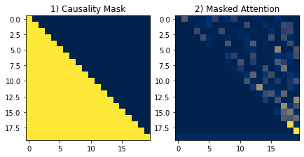

```python
# Create a dummy tensor
sample_tensor = tf.random.uniform((20, 20), minval=-3, maxval=3)

# Generate masks
_, _, dec_mask = generate_masks(tf.zeros((1, 20)), tf.zeros((1, 20)))

# Directly use the causality mask instead of the combined dec_mask
causality_mask = generate_causality_mask(20, 20)
mask = causality_mask

fig = plt.figure(figsize=(7, 7))

ax1 = fig.add_subplot(121)
ax2 = fig.add_subplot(122)

ax1.set_title('1) Causality Mask')
ax2.set_title('2) Masked Attention')

# 시각화 부분에서 마스크 값을 바꿔서 보여주는 것만 변경합니다.
ax1.imshow(1 - mask.numpy(), cmap='cividis')

# 마스크된 텐서를 수정합니다.
masked_tensor = sample_tensor - (1 - mask) * 1e9 # 마스킹되지 않은 부분을 큰 음수값으로 만듭니다.
ax2.imshow(tf.nn.softmax(masked_tensor, axis=-1).numpy(), cmap='cividis')

plt.show()
```

### Step 4. 훈련하기

#### 1. 2 Layer를 가지는 Transformer 선언 (하이퍼파라미터는 자유롭게 조절)

```python
transformer = Transformer(
    n_layers=2,
    d_model=512,
    n_heads=8,
    d_ff=2048,
    src_vocab_size=SRC_VOCAB_SIZE,
    tgt_vocab_size=TGT_VOCAB_SIZE,
    pos_len=200, # 예를 들어 200으로 설정. 실제 값은 문장의 최대 길이에 따라 설정해야 합니다.
    dropout=0.2,
    shared=True
)
```

#### 2. Learning Rate Scheduler 선언 및 이를 포함한 Adam Optimizer 선언

```python
class LearningRateScheduler(tf.keras.optimizers.schedules.LearningRateSchedule):
    def __init__(self, d_model, warmup_steps=4000):
        super(LearningRateScheduler, self).__init__()
        self.d_model = d_model
        self.warmup_steps = warmup_steps

    def __call__(self, step):
        arg1 = step ** -0.5
        arg2 = step * (self.warmup_steps ** -1.5)

        return (self.d_model ** -0.5) * tf.math.minimum(arg1, arg2)
```

```python
learning_rate = LearningRateScheduler(512)
```

```python
optimizer = tf.keras.optimizers.Adam(learning_rate,
                                     beta_1=0.9,
                                     beta_2=0.98,
                                     epsilon=1e-9)
```

```python
# Learning rate scheduling 시각화
```

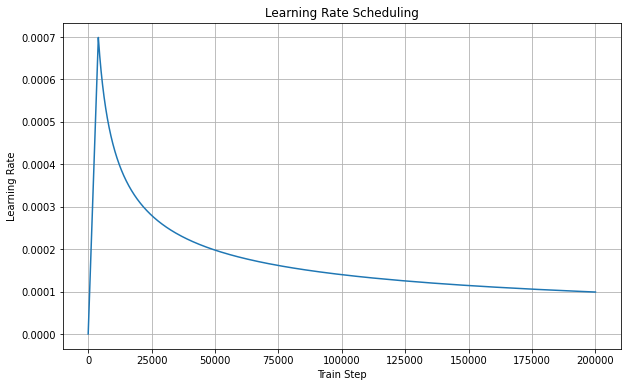

```python
plt.figure(figsize=(10, 6))
plt.plot(learning_rate(tf.range(200000, dtype=tf.float32)))
plt.ylabel("Learning Rate")
plt.xlabel("Train Step")
plt.title("Learning Rate Scheduling")
plt.grid(True)
plt.show()
```

#### 3. Loss 함수 정의

```python
loss_object = tf.keras.losses.SparseCategoricalCrossentropy(
    from_logits=True, reduction='none')
```

```python
def loss_function(real, pred):
    mask = tf.math.logical_not(tf.math.equal(real, 0))
    loss_ = loss_object(real, pred)

    # Masking 되지 않은 입력의 개수로 Scaling하는 과정
    mask = tf.cast(mask, dtype=loss_.dtype)
    loss_ *= mask

    return tf.reduce_sum(loss_)/tf.reduce_sum(mask)
```

#### 4. train_step 함수 정의

```python
@tf.function()
def train_step(src, tgt, model, optimizer):
    gold = tgt[:, 1:]

    enc_mask, dec_enc_mask, dec_mask = generate_masks(src, tgt)

    # 계산된 loss에 tf.GradientTape()를 적용해 학습 진행
    with tf.GradientTape() as tape:
        predictions, enc_attns, dec_attns, dec_enc_attns = \
        model(src, tgt, enc_mask, dec_enc_mask, dec_mask)
        loss = loss_function(gold, predictions[:, :-1])

    gradients = tape.gradient(loss, model.trainable_variables)            # 손실에 대한 모델의 훈련 가능한 변수의 gradient 계산
    optimizer.apply_gradients(zip(gradients, model.trainable_variables))  # 계산된 gradient를 optimizer에 적용하여 변수 업데이트

    return loss, enc_attns, dec_attns, dec_enc_attns
```

#### 5. 학습 진행

##### 학습/평가 및 시각화 관련 주요 함수 생성

```python
# Attention 시각화 함수
```

```python
def visualize_attention(src, tgt, enc_attns, dec_attns, dec_enc_attns):
    def draw(data, ax, x="auto", y="auto"):
        import seaborn
        seaborn.heatmap(data,
                        square=True,
                        vmin=0.0, vmax=1.0,
                        cbar=False, ax=ax,
                        xticklabels=x,
                        yticklabels=y)

    for layer in range(0, 2, 1):
        fig, axs = plt.subplots(1, 4, figsize=(20, 10))
        print("Encoder Layer", layer + 1)
        for h in range(4):
            draw(enc_attns[layer][0, h, :len(src), :len(src)], axs[h], src, src)
        plt.show()

    for layer in range(0, 2, 1):
        fig, axs = plt.subplots(1, 4, figsize=(20, 10))
        print("Decoder Self Layer", layer+1)
        for h in range(4):
            draw(dec_attns[layer][0, h, :len(tgt), :len(tgt)], axs[h], tgt, tgt)
        plt.show()

        print("Decoder Src Layer", layer+1)
        fig, axs = plt.subplots(1, 4, figsize=(20, 10))
        for h in range(4):
            draw(dec_enc_attns[layer][0, h, :len(tgt), :len(src)], axs[h], src, tgt)
        plt.show()
```

```python
# 올바른 Attention Map을 확인하기 위해 한국어를 지원하는 폰트로 변경
```

```python
import matplotlib as mpl
import matplotlib.pyplot as plt
import matplotlib.font_manager as fm

%config InlineBackend.figure_format = 'retina'

fontpath = '/usr/share/fonts/truetype/nanum/NanumBarunGothic.ttf'
font = fm.FontProperties(fname=fontpath, size=9)
plt.rc('font', family='NanumBarunGothic')
mpl.font_manager.findfont(font)
```

```
'/usr/share/fonts/truetype/nanum/NanumBarunGothic.ttf'
```

```python
# 번역 생성 함수
```

```python
def evaluate(sentence, model, src_tokenizer, tgt_tokenizer):
    sentence = preprocess_sentence(sentence)

    pieces = src_tokenizer.encode_as_pieces(sentence)
    tokens = src_tokenizer.encode_as_ids(sentence)

    _input = tf.keras.preprocessing.sequence.pad_sequences([tokens],
                                                           maxlen=enc_train.shape[-1],
                                                           padding='post')

    ids = []
    output = tf.expand_dims([tgt_tokenizer.bos_id()], 0)
    for i in range(dec_train.shape[-1]):
        enc_padding_mask, combined_mask, dec_padding_mask = \
        generate_masks(_input, output)

        predictions, enc_attns, dec_attns, dec_enc_attns =\
        model(_input,
              output,
              enc_padding_mask,
              combined_mask,
              dec_padding_mask)

        predicted_id = \
        tf.argmax(tf.math.softmax(predictions, axis=-1)[0, -1]).numpy().item()

        if tgt_tokenizer.eos_id() == predicted_id:
            result = tgt_tokenizer.decode_ids(ids)
            return pieces, result, enc_attns, dec_attns, dec_enc_attns

        ids.append(predicted_id)
        output = tf.concat([output, tf.expand_dims([predicted_id], 0)], axis=-1)

    result = tgt_tokenizer.decode_ids(ids)

    return pieces, result, enc_attns, dec_attns, dec_enc_attns
```

```python
# 번역 생성 및 Attention 시각화 결합 함수
```

```python
def translate(sentence, model, src_tokenizer, tgt_tokenizer, plot_attention=False):
    pieces, result, enc_attns, dec_attns, dec_enc_attns = \
    evaluate(sentence, model, src_tokenizer, tgt_tokenizer)

    print('Input: %s' % (sentence))
    print('Predicted translation: {}'.format(result))

    if plot_attention:
        visualize_attention(pieces, result.split(), enc_attns, dec_attns, dec_enc_attns)
```

##### 학습 및 번역 결과

```
Input: 오바마는 대통령이다.
Predicted translation: obamas obama is a lot of obama .
Input: 시민들은 도시 속에 산다.
Predicted translation: the number of the beach are in the area .
Input: 커피는 필요 없다.
Predicted translation: theyre not a lot of the right .
Input: 일곱 명의 사망자가 발생했다.
Predicted translation: the quake was killed by the dead .
```

```
Input: 오바마는 대통령이다.
Predicted translation: obama is president of the obamas president .
Input: 시민들은 도시 속에 산다.
Predicted translation: the city is the worlds largest city .
Input: 커피는 필요 없다.
Predicted translation: coffee is a coffee .
Input: 일곱 명의 사망자가 발생했다.
Predicted translation: the death toll is reportedly .
```

```
Input: 오바마는 대통령이다.
Predicted translation: obamas aide to the president .
Input: 시민들은 도시 속에 산다.
Predicted translation: the crowd is the worst in the city of the city of the city .
Input: 커피는 필요 없다.
Predicted translation: the not needed to be needed .
Input: 일곱 명의 사망자가 발생했다.
Predicted translation: the three days of the deaths of the deaths .
```

```
Input: 오바마는 대통령이다.
Predicted translation: obamas president .
Input: 시민들은 도시 속에 산다.
Predicted translation: the city of the city of the city of the city of the city .
Input: 커피는 필요 없다.
Predicted translation: coffee isnt necessary .
Input: 일곱 명의 사망자가 발생했다.
Predicted translation: the death toll from the death toll rose .
```

```
Input: 오바마는 대통령이다.
Predicted translation: obama is the first president .
Input: 시민들은 도시 속에 산다.
Predicted translation: the valley is the day of the mountain .
Input: 커피는 필요 없다.
Predicted translation: coffee needs to do with coffee .
Input: 일곱 명의 사망자가 발생했다.
Predicted translation: death toll rose to . on monday .
```

```
Input: 오바마는 대통령이다.
Predicted translation: obama is president .
Input: 시민들은 도시 속에 산다.
Predicted translation: they are the city of the city .
Input: 커피는 필요 없다.
Predicted translation: no need for a precious alternative .
Input: 일곱 명의 사망자가 발생했다.
Predicted translation: on sunday , people were killed .
```

```
Input: 오바마는 대통령이다.
Predicted translation: obama is now president .
Input: 시민들은 도시 속에 산다.
Predicted translation: some of the city is in the mountains .
Input: 커피는 필요 없다.
Predicted translation: nothing needs to do .
Input: 일곱 명의 사망자가 발생했다.
Predicted translation: five seven including the seven deaths were reported .
```

```
Input: 오바마는 대통령이다.
Predicted translation: obamas president .
Input: 시민들은 도시 속에 산다.
Predicted translation: they are in the city of populated by the mountains of cities
Input: 커피는 필요 없다.
Predicted translation: nothing cannot afford .
Input: 일곱 명의 사망자가 발생했다.
Predicted translation: five deaths were reportedly trapped under the deaths .
```

```
Input: 오바마는 대통령이다.
Predicted translation: obama holds out of office .
Input: 시민들은 도시 속에 산다.
Predicted translation: just a city of troops are just in cities .
Input: 커피는 필요 없다.
Predicted translation: its not need to town .
Input: 일곱 명의 사망자가 발생했다.
Predicted translation: nine deaths were reported killed wednesday .
```

```
Input: 오바마는 대통령이다.
Predicted translation: obama can be proud .
Input: 시민들은 도시 속에 산다.
Predicted translation: just a laid out at my life
Input: 커피는 필요 없다.
Predicted translation: nothing need for a fine .
Input: 일곱 명의 사망자가 발생했다.
Predicted translation: seven people were killed , seven including seven people .
```

```
Input: 오바마는 대통령이다.
Predicted translation: obama is the first man to be president .
Input: 시민들은 도시 속에 산다.
Predicted translation: just a city in the city is in the city .
Input: 커피는 필요 없다.
Predicted translation: its a fine for coffee .
Input: 일곱 명의 사망자가 발생했다.
Predicted translation: seven people were among the dead .
```

```
Input: 오바마는 대통령이다.
Predicted translation: obamas president .
Input: 시민들은 도시 속에 산다.
Predicted translation: just a city is just a city in urban .
Input: 커피는 필요 없다.
Predicted translation: its a fine for coffee .
Input: 일곱 명의 사망자가 발생했다.
Predicted translation: seven people were among the death toll was injured thursday .
```

```
Input: 오바마는 대통령이다.
Predicted translation: obama may be president .
Input: 시민들은 도시 속에 산다.
Predicted translation: just a city of myit .
Input: 커피는 필요 없다.
Predicted translation: its fine for coffee need .
Input: 일곱 명의 사망자가 발생했다.
Predicted translation: , nine have been killed , .
```

```
Input: 오바마는 대통령이다.
Predicted translation: obama . the president was a leader .
Input: 시민들은 도시 속에 산다.
Predicted translation: just a city in the city .
Input: 커피는 필요 없다.
Predicted translation: its a fine for you .
Input: 일곱 명의 사망자가 발생했다.
Predicted translation: five people were killed , among the seven people .
```

```
Input: 오바마는 대통령이다.
Predicted translation: obama is president .
Input: 시민들은 도시 속에 산다.
Predicted translation: just as many cities in the city .
Input: 커피는 필요 없다.
Predicted translation: its enough for cup alternatives to need
Input: 일곱 명의 사망자가 발생했다.
Predicted translation: five people were killed , including seven civilian deaths thursday .
```

```
Input: 오바마는 대통령이다.
Predicted translation: obama is the president to get him .
Input: 시민들은 도시 속에 산다.
Predicted translation: just a city to urban one is a heavy holiday .
Input: 커피는 필요 없다.
Predicted translation: coffee beams need for coffee
Input: 일곱 명의 사망자가 발생했다.
Predicted translation: nine deaths were killed there were the death toll monday .
```

```
Input: 오바마는 대통령이다.
Predicted translation: obama is in the president .
Input: 시민들은 도시 속에 산다.
Predicted translation: just as the city in the city .
Input: 커피는 필요 없다.
Predicted translation: it needs to be fine .
Input: 일곱 명의 사망자가 발생했다.
Predicted translation: , deaths on sunday , .
```

```
Input: 오바마는 대통령이다.
Predicted translation: obama is in the president .
Input: 시민들은 도시 속에 산다.
Predicted translation: just a city in new york city is a city .
Input: 커피는 필요 없다.
Predicted translation: its a fine for coffeeca .
Input: 일곱 명의 사망자가 발생했다.
Predicted translation: deaths occurred seven deaths monday .
```

```
Input: 오바마는 대통령이다.
Predicted translation: obama is the first person in the president .
Input: 시민들은 도시 속에 산다.
Predicted translation: they are in cities in the city .
Input: 커피는 필요 없다.
Predicted translation: the coffee needs . need for their needs .
Input: 일곱 명의 사망자가 발생했다.
Predicted translation: deaths on seven people were killed , among the seven deaths across the seven deaths were reported .
```

```
Input: 오바마는 대통령이다.
Predicted translation: obama has runs president .
Input: 시민들은 도시 속에 산다.
Predicted translation: just a city in the city is mayor .
Input: 커피는 필요 없다.
Predicted translation: its a fine need for coffee
Input: 일곱 명의 사망자가 발생했다.
Predicted translation: deaths on seven people were killed .

Attention Maps after Training:
Input: 오바마는 대통령이다.
Predicted translation: obama has runs president .
Encoder Layer 1
```

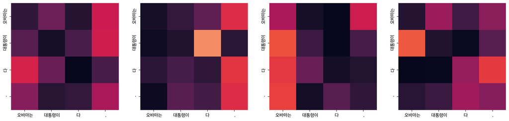

```
Encoder Layer 2
```

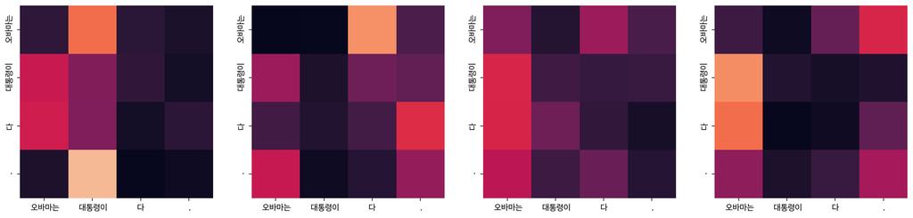

```
Decoder Self Layer 1
```

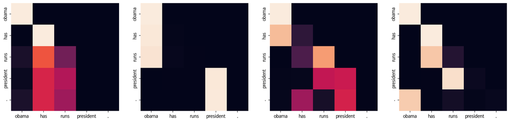

```
Decoder Src Layer 1
```

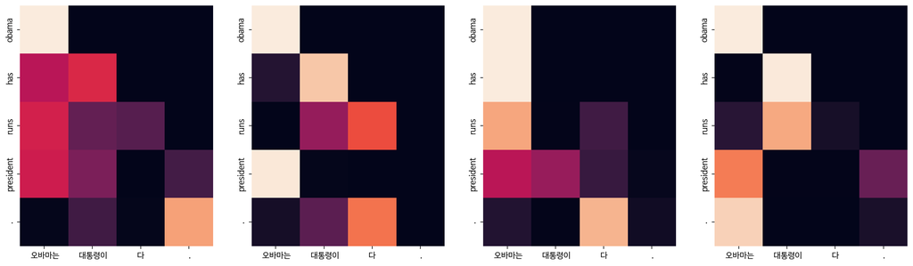

```
Decoder Self Layer 2
```

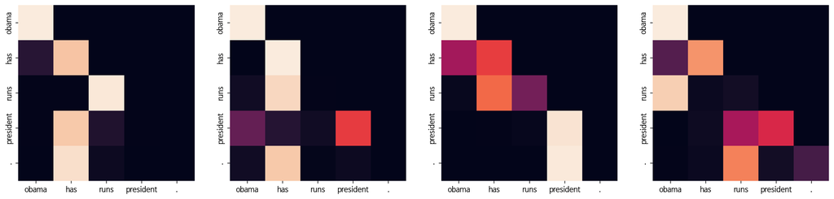

```
Decoder Src Layer 2
```

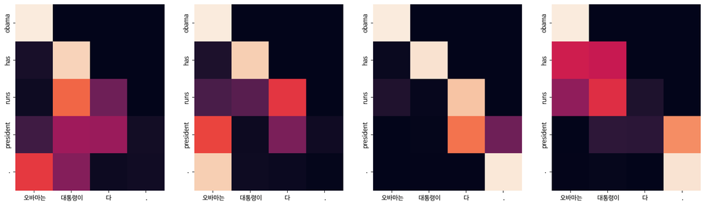

```
Input: 시민들은 도시 속에 산다.
Predicted translation: just a city in the city is mayor .
Encoder Layer 1
```

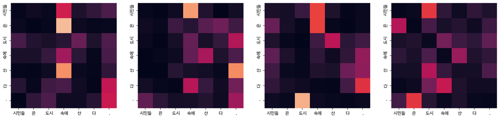

```
Encoder Layer 2
```

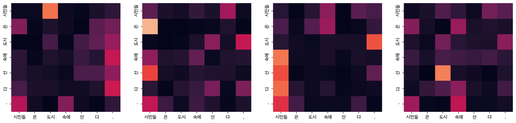

```
Decoder Self Layer 1
```

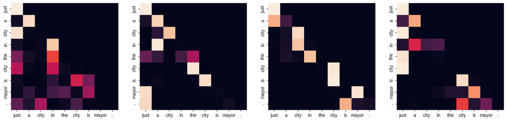

```
Decoder Src Layer 1
```

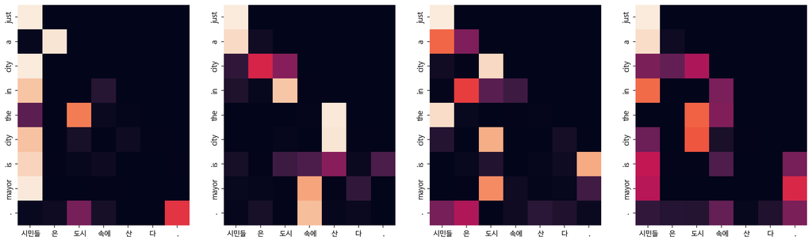

```
Decoder Self Layer 2
```

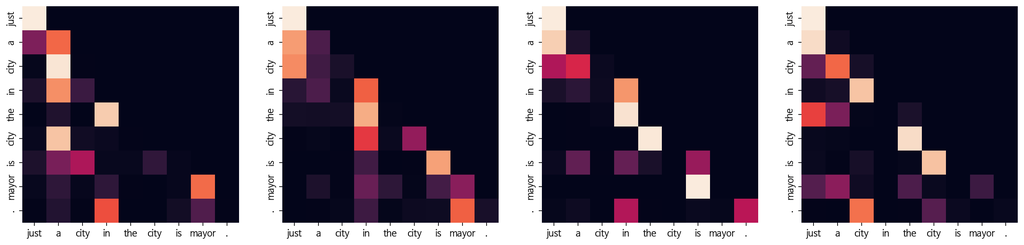

```
Decoder Src Layer 2
```

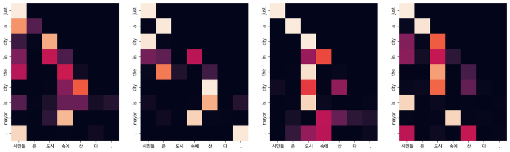

```
Input: 커피는 필요 없다.
Predicted translation: its a fine need for coffee
Encoder Layer 1
```

[12 more figures not shown]

```python
from tqdm import tqdm_notebook

BATCH_SIZE = 64
EPOCHS = 20

examples = [
    "오바마는 대통령이다.",
    "시민들은 도시 속에 산다.",
    "커피는 필요 없다.",
    "일곱 명의 사망자가 발생했다."
]

# 학습 도중 번역 결과만 출력하는 함수
def simple_translate(sentence, model, src_tokenizer, tgt_tokenizer):
    pieces, result, _, _, _ = evaluate(sentence, model, src_tokenizer, tgt_tokenizer)
    print('Input: %s' % (sentence))
    print('Predicted translation: {}'.format(result))

for epoch in range(EPOCHS):
    total_loss = 0

    idx_list = list(range(0, enc_train.shape[0], BATCH_SIZE))
    random.shuffle(idx_list)
    t = tqdm_notebook(idx_list)

    for (batch, idx) in enumerate(t):
        batch_loss, _, _, _ = train_step(enc_train[idx:idx+BATCH_SIZE],
                                         dec_train[idx:idx+BATCH_SIZE],
                                         transformer,
                                         optimizer)

        total_loss += batch_loss

        t.set_description_str('Epoch %2d' % (epoch + 1))
        t.set_postfix_str('Loss %.4f' % (total_loss.numpy() / (batch + 1)))

    # 학습 도중 번역 결과만 출력
    for example in examples:
        simple_translate(example, transformer, ko_tokenizer, en_tokenizer)

# 학습이 끝난 후 Attention Map 출력
print("\nAttention Maps after Training:")
for example in examples:
    translate(example, transformer, ko_tokenizer, en_tokenizer, plot_attention=True)
```

##### Test(번역) 및 Attention Map 출력

```python
def custom_translate(input_text):
    translate(input_text, transformer, ko_tokenizer, en_tokenizer, plot_attention=True)
```

```python
# Additional Test 1
```

```
Input: 한반도의 비핵화를 위한 정책을 지지한다.
Predicted translation: peninsula plan to support a peninsula for peninsula .
Encoder Layer 1
```

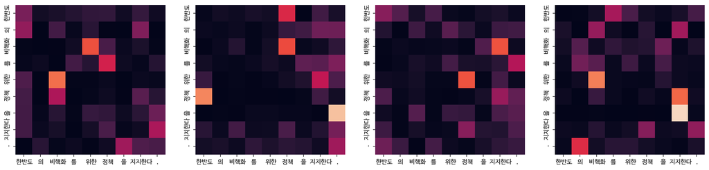

```
Encoder Layer 2
```

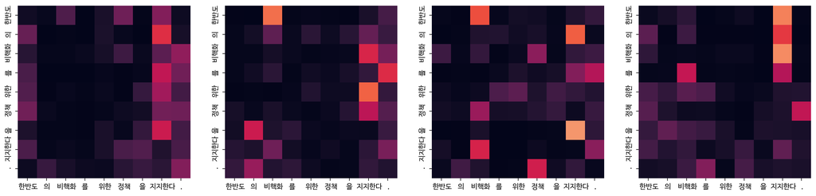

```
Decoder Self Layer 1
```

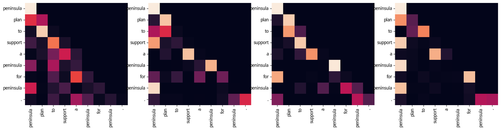

```
Decoder Src Layer 1
```

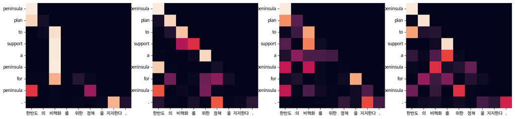

```
Decoder Self Layer 2
```

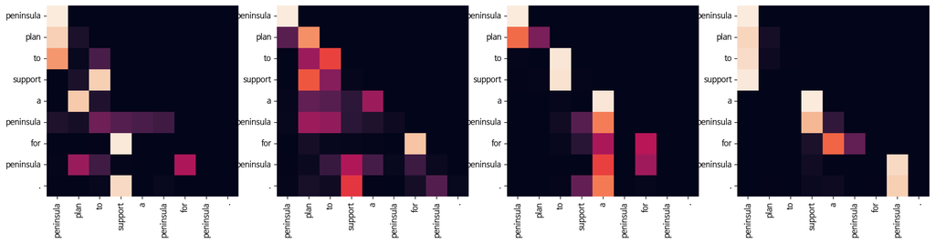

```
Decoder Src Layer 2
```

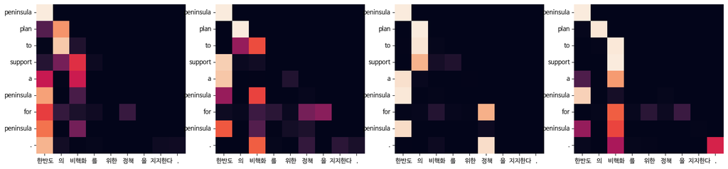

```python
input_text = "한반도의 비핵화를 위한 정책을 지지한다."
custom_translate(input_text)
```

```python
# Additional Test 2
```

```
Input: 그 사고로 수많은 사람이 죽었다.
Predicted translation: the couple many thousand people are died in .
Encoder Layer 1
```

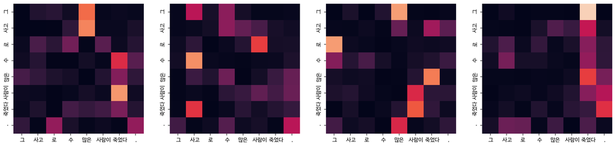

```
Encoder Layer 2
```

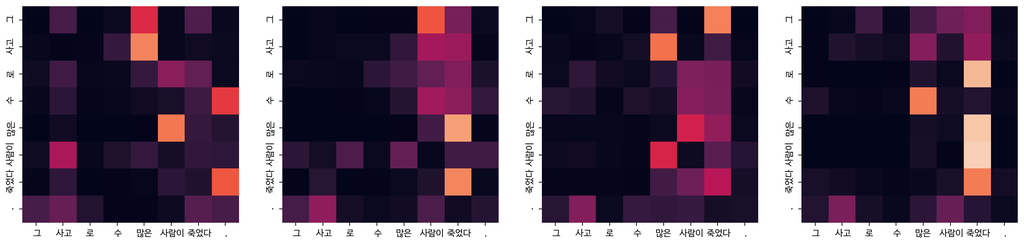

```
Decoder Self Layer 1
```

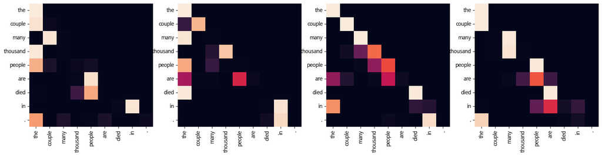

```
Decoder Src Layer 1
```

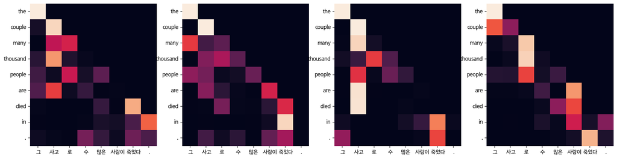

```
Decoder Self Layer 2
```

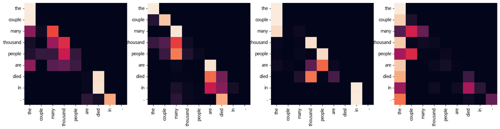

```
Decoder Src Layer 2
```

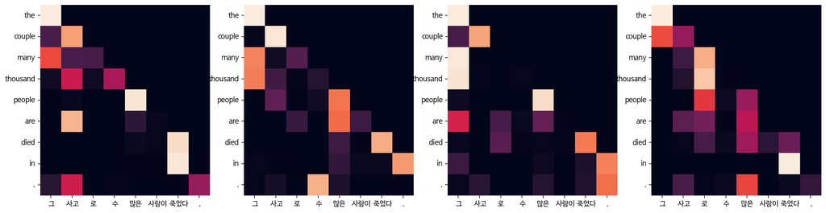

```python
input_text = "그 사고로 수많은 사람이 죽었다."
custom_translate(input_text)
```